# Community Contribution

Author

Jason Cheung (jc6405)

# Background to why `Naniar` Package

1. How many missing values are there ?
2. Are there any patterns to these missing data?
3. Should we interpolate them as it may contain useful information or just delete them?

# What is `Naniar` Package?

The `Naniar` Package is a library that is primarily used for visualization and to help with missing values in your dataset

Sources that I used:

1. https://tmb.njtierney.com/explore-missings-big-picture
2. https://naniar.njtierney.com/articles/naniar-visualisation.html
3. https://cran.r-project.org/web/packages/naniar/vignettes/getting-started-w- naniar.html

# Loading Libraries

```r
library(ggplot2)
library(naniar)
library(dplyr)
library(tidyverse)
```

# Benefit #1 of `Naniar` Package:

Allows you to see missing value in data set in a much cleaner and organize format

```r
mycars <- mtcars
mycars[,"gear"] <- NA
mycars[10:20, 3:5] <- NA
for (i in 1:10) mycars[sample(32,1), sample(11,1)] <- NA
```

```r
head(mycars)
```

```
                   mpg cyl disp  hp drat    wt  qsec vs am gear carb
Mazda RX4         21.0   6   NA 110 3.90 2.620 16.46  0  1   NA    4
Mazda RX4 Wag     21.0   6  160 110 3.90 2.875 17.02  0  1   NA    4
Datsun 710        22.8   4  108  93 3.85 2.320 18.61  1  1   NA    1
Hornet 4 Drive    21.4   6   NA 110 3.08 3.215 19.44  1  0   NA    1
Hornet Sportabout   NA   8  360 175   NA 3.440 17.02  0  0   NA    2
Valiant           18.1   6  225 105 2.76 3.460 20.22  1  0   NA    1
```

```r
summary(mycars)
```

```
      mpg             cyl             disp             hp
 Min.   :10.40   Min.   :4.000   Min.   : 79.0   Min.   : 62.0
 1st Qu.:15.35   1st Qu.:4.000   1st Qu.:120.5   1st Qu.: 97.0
 Median :19.20   Median :6.000   Median :153.3   Median :110.0
 Mean   :20.14   Mean   :6.188   Mean   :216.9   Mean   :146.4
 3rd Qu.:22.80   3rd Qu.:8.000   3rd Qu.:342.0   3rd Qu.:175.0
 Max.   :33.90   Max.   :8.000   Max.   :400.0   Max.   :335.0
 NA's   :1                       NA's   :14      NA's   :11
      drat             wt             qsec             vs
 Min.   :2.760   Min.   :1.513   Min.   :14.50   Min.   :0.0000
 1st Qu.:3.195   1st Qu.:2.581   1st Qu.:16.89   1st Qu.:0.0000
 Median :3.715   Median :3.325   Median :17.60   Median :0.0000
 Mean   :3.625   Mean   :3.217   Mean   :17.81   Mean   :0.4516
 3rd Qu.:3.905   3rd Qu.:3.610   3rd Qu.:18.75   3rd Qu.:1.0000
 Max.   :4.430   Max.   :5.424   Max.   :22.90   Max.   :1.0000
 NA's   :12                      NA's   :1       NA's   :1
       am           gear              carb
 Min.   :0.0000   Mode:logical   Min.   :1.000
 1st Qu.:0.0000   NA's:32        1st Qu.:2.000
 Median :0.0000                  Median :2.000
 Mean   :0.3871                  Mean   :2.812
 3rd Qu.:1.0000                  3rd Qu.:4.000
 Max.   :1.0000                  Max.   :8.000
 NA's   :1
```

```r
colSums(is.na(mycars))
```

```
 mpg  cyl disp   hp drat   wt qsec   vs   am gear carb
   1    0   14   11   12    0    1    1    1   32    0
```

```r
# colSums(is.na(mycars), decreasing = TRUE)
```

```r
rowSums(is.na(mycars))
```

```
          Mazda RX4       Mazda RX4 Wag          Datsun 710      Hornet 4 Drive
                  2                   1                   1                   2
  Hornet Sportabout             Valiant          Duster 360           Merc 240D
                  3                   1                   1                   1
           Merc 230            Merc 280           Merc 280C          Merc 450SE
                  1                   4                   4                   4
         Merc 450SL         Merc 450SLC  Cadillac Fleetwood Lincoln Continental
                  5                   4                   4                   4
  Chrysler Imperial            Fiat 128         Honda Civic      Toyota Corolla
                  4                   4                   4                   4
      Toyota Corona    Dodge Challenger         AMC Javelin          Camaro Z28
                  1                   1                   1                   1
   Pontiac Firebird           Fiat X1-9       Porsche 914-2        Lotus Europa
                  1                   2                   1                   1
     Ford Pantera L        Ferrari Dino       Maserati Bora          Volvo 142E
                  1                   1                   3                   1
```

Issue with above is that it displays result in a numeric class and you cannot order, whereas the functions in `Naniar` package keeps it in a data frame

```r
# tells you number of missing data in each col
head(miss_var_summary(mycars))
```

```
# A tibble: 6 × 3
  variable n_miss pct_miss
  <chr>     <int>    <num>
1 gear         32   100
2 disp         14    43.8
3 drat         12    37.5
4 hp           11    34.4
5 mpg           1     3.12
6 qsec          1     3.12
```

```r
# tells you number of missing data in each row
head(miss_case_summary(mycars))
```

```
# A tibble: 6 × 3
   case n_miss pct_miss
  <int>  <int>    <dbl>
1    13      5     45.5
2    10      4     36.4
3    11      4     36.4
4    12      4     36.4
5    14      4     36.4
6    15      4     36.4
```

```r
# Compatible with dplyr library as it keeps it in a dataframe class
mycars |>
  miss_var_summary() |>
  filter(n_miss != 0) |>
  head()
```

```
# A tibble: 6 × 3
  variable n_miss pct_miss
  <chr>     <int>    <num>
1 gear         32   100
2 disp         14    43.8
3 drat         12    37.5
4 hp           11    34.4
5 mpg           1     3.12
6 qsec          1     3.12
```

```r
mycars |>
  group_by(cyl) |>
  miss_var_summary() |>
  filter(n_miss == 0) |>
  head()
```

```
# A tibble: 6 × 4
# Groups:   cyl [1]
    cyl variable n_miss pct_miss
  <dbl> <chr>     <int>    <num>
1     6 mpg           0        0
2     6 wt            0        0
3     6 qsec          0        0
4     6 vs            0        0
5     6 am            0        0
6     6 carb          0        0
```

# Limitation of Benefit #1: Unable to display missing rows and columns

```r
na_rows <- mycars[rowSums(is.na(mycars)) > 0, ]
head(na_rows)
```

```
                   mpg cyl disp  hp drat    wt  qsec vs am gear carb
Mazda RX4         21.0   6   NA 110 3.90 2.620 16.46  0  1   NA    4
Mazda RX4 Wag     21.0   6  160 110 3.90 2.875 17.02  0  1   NA    4
Datsun 710        22.8   4  108  93 3.85 2.320 18.61  1  1   NA    1
Hornet 4 Drive    21.4   6   NA 110 3.08 3.215 19.44  1  0   NA    1
Hornet Sportabout   NA   8  360 175   NA 3.440 17.02  0  0   NA    2
Valiant           18.1   6  225 105 2.76 3.460 20.22  1  0   NA    1
```

# Benefit #2 of `Naniar` Package:

Allows you to quickly visualize pattern in missing values in the data set

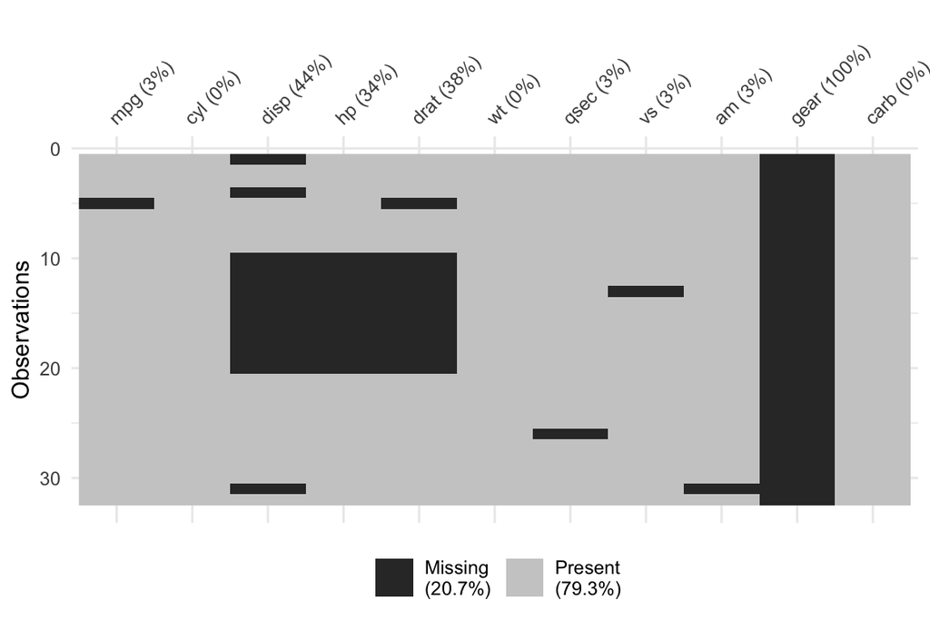

```r
# Instead of looking at NA Value through data frame, can just plot it instead
# Allows us to also see pattern of missing value and if there are cluster of
# missing values happening
vis_miss(mycars)
```

```r
mycars$am <-
  fct_recode(factor(mycars$am),
  'Automatic' = '0',
  'Manual' = '1')
```

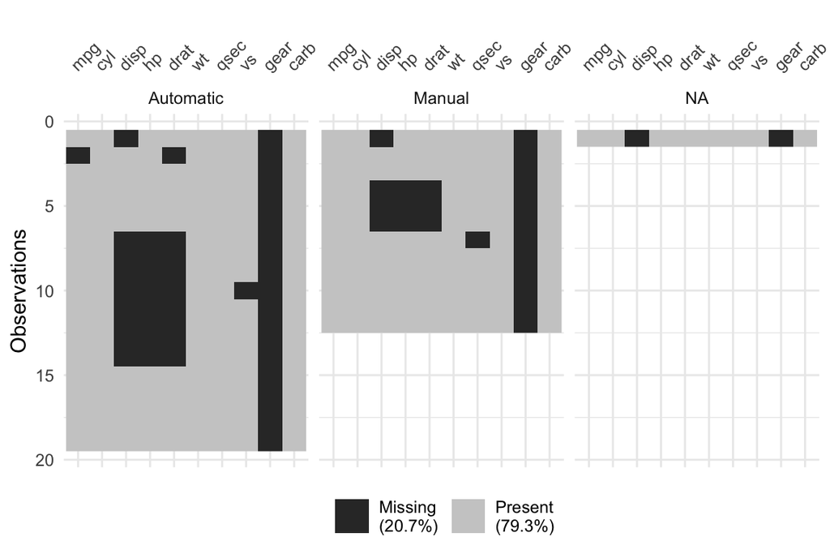

```r
# Cluster: Orders the graph in a hierarchical order that arranges row order
# given missing value
vis_miss(mycars, cluster = TRUE, facet = am)
```

# Limitation of Benefit #2: Faceting Label Loss

Try to get the percentage missing for each column when faceting as by vis_miss default does not include it, which I was able to do below but had no idea how to manually insert these missing percentage into the graph itself though…

```r
test <- mycars |>
  group_by(am) |>
  miss_var_summary()

test |>
  select(am, variable, pct_miss) |>
  filter(am == 'Manual') |>
  mutate(variable = factor(variable, levels = colnames(mycars))) |>
  arrange(variable)
```

```
# A tibble: 10 × 3
# Groups:   am [1]
   am     variable pct_miss
   <fct>  <fct>       <num>
 1 Manual mpg          0
 2 Manual cyl          0
 3 Manual disp        33.3
 4 Manual hp          25
 5 Manual drat        25
 6 Manual wt           0
 7 Manual qsec         8.33
 8 Manual vs           0
 9 Manual gear       100
10 Manual carb         0
```

# Few more `Naniar` functions to identify Missing Values Pattern

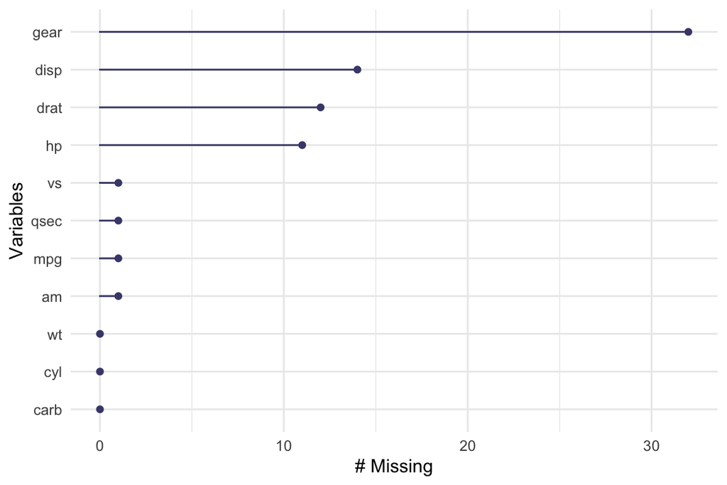

```r
gg_miss_var(mycars)
```

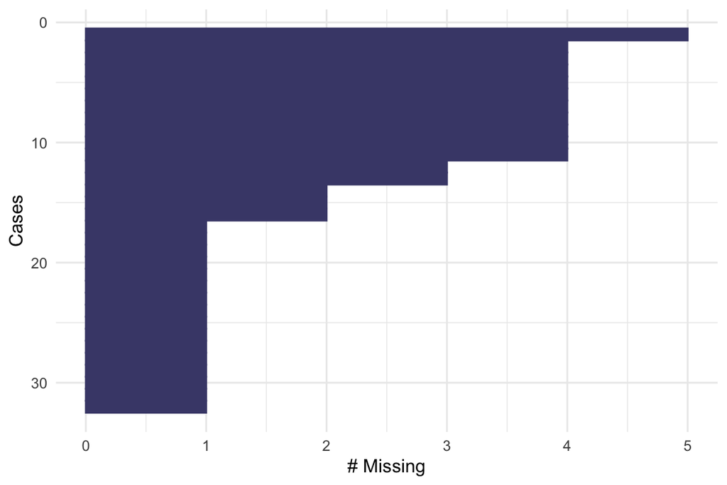

```r
gg_miss_case(mycars)
```

# Benefit #3: `Naniar` Package:

Typical problem that I face: Now that you know what data are missing, what do we do now? Should we remove it? Should we keep it? Does it provide any value? Is there a pattern corresponded to the NA values? I don’t know what to do

```r
head(mycars)
```

```
                   mpg cyl disp  hp drat    wt  qsec vs        am gear carb
Mazda RX4         21.0   6   NA 110 3.90 2.620 16.46  0    Manual   NA    4
Mazda RX4 Wag     21.0   6  160 110 3.90 2.875 17.02  0    Manual   NA    4
Datsun 710        22.8   4  108  93 3.85 2.320 18.61  1    Manual   NA    1
Hornet 4 Drive    21.4   6   NA 110 3.08 3.215 19.44  1 Automatic   NA    1
Hornet Sportabout   NA   8  360 175   NA 3.440 17.02  0 Automatic   NA    2
Valiant           18.1   6  225 105 2.76 3.460 20.22  1 Automatic   NA    1
```

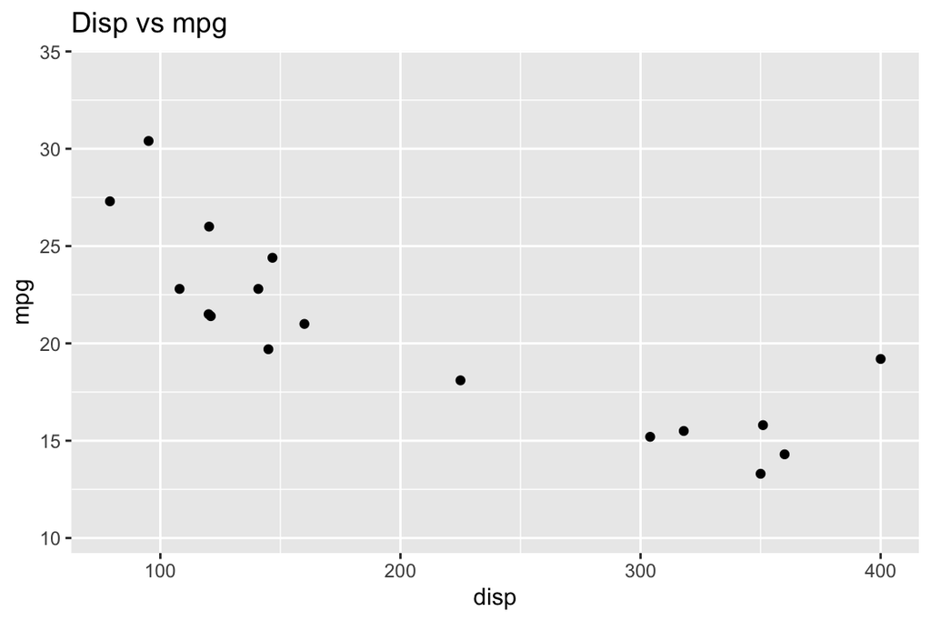

```r
# ggplot would automatically not include NA values (can be seen in console)
ggplot(mycars, aes(x = disp, y = mpg)) +
  geom_point() +
  labs(title = "Disp vs mpg")
```

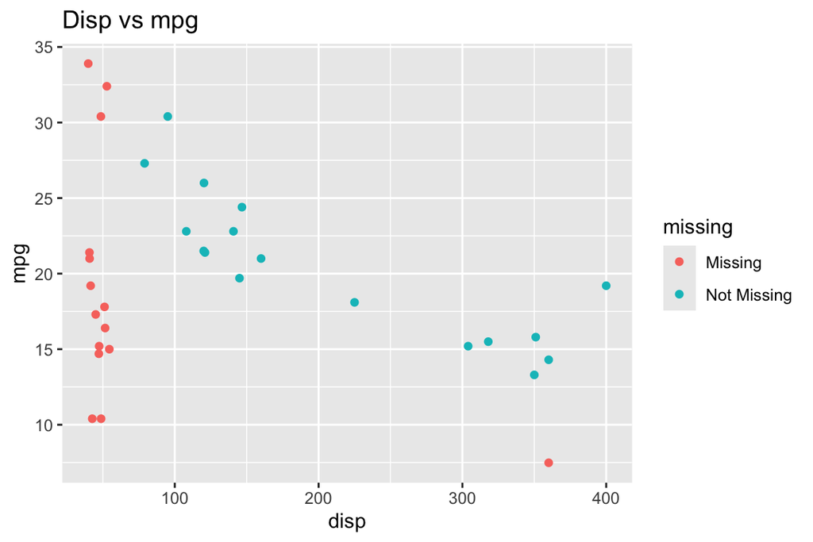

```r
# Generates legend to by itself
ggplot(mycars, aes(x = disp, y = mpg)) +
  geom_miss_point() +
  labs(title = "Disp vs mpg")
```

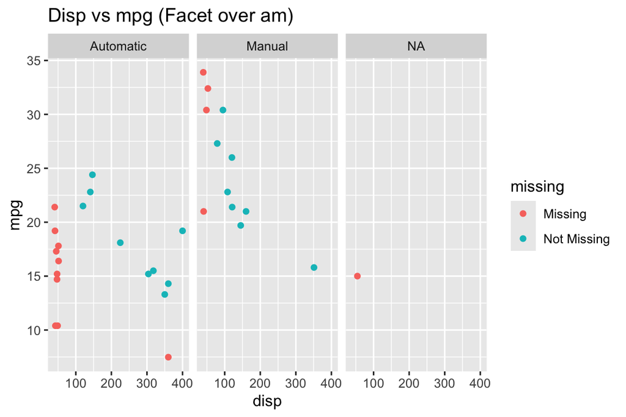

```r
ggplot(mycars, aes(x = disp, y = mpg)) +
  geom_miss_point() +
  facet_wrap(~am) +
  labs(title = "Disp vs mpg (Facet over am)")
```

# Workaround:

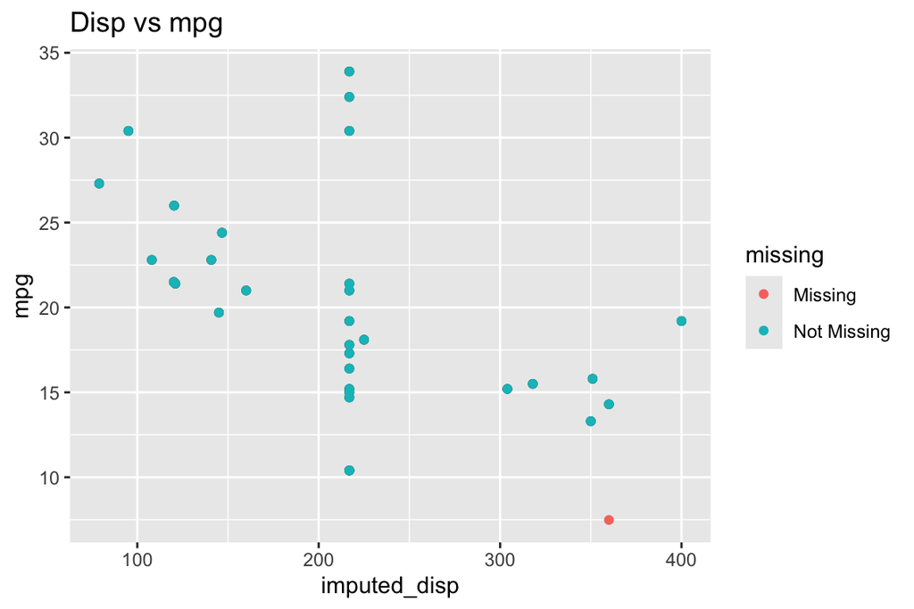

```r
mycars |>
  mutate(imputed_disp = replace(disp, is.na(disp), mean(disp, na.rm = TRUE)))|>
  ggplot(aes(x = imputed_disp, y = mpg)) +
  geom_point() +
  geom_miss_point() +
  labs(title = "Disp vs mpg")
```